# 6306_Case_study_1

Caitlin Endler and Rashmi Patel

2/21/2021

Budweiser is exploring the craft brewery market. We will review current trends for beer in this industry and provide insight for growth opportunities in the market.

Import and inspect data

```r
library(tidyverse)
```

```r
library(class)
library(maps)
library(caret)
#Read Beers.csv
beers_data=read.csv(file.choose(), header=TRUE)
head(beers_data)
```

```
##                  Name Beer_ID   ABV IBU Brewery_id
## 1            Pub Beer    1436 0.050  NA        409
## 2         Devil's Cup    2265 0.066  NA        178
## 3 Rise of the Phoenix    2264 0.071  NA        178
## 4            Sinister    2263 0.090  NA        178
## 5       Sex and Candy    2262 0.075  NA        178
## 6        Black Exodus    2261 0.077  NA        178
##                            Style Ounces
## 1            American Pale Lager     12
## 2        American Pale Ale (APA)     12
## 3                   American IPA     12
## 4 American Double / Imperial IPA     12
## 5                   American IPA     12
## 6                  Oatmeal Stout     12
```

```r
dim(beers_data)
```

```
## [1] 2410    7
```

```r
Beers=beers_data%>%rename(Beer_Name=Name)
head(Beers)
```

```
##             Beer_Name Beer_ID   ABV IBU Brewery_id
## 1            Pub Beer    1436 0.050  NA        409
## 2         Devil's Cup    2265 0.066  NA        178
## 3 Rise of the Phoenix    2264 0.071  NA        178
## 4            Sinister    2263 0.090  NA        178
## 5       Sex and Candy    2262 0.075  NA        178
## 6        Black Exodus    2261 0.077  NA        178
##                            Style Ounces
## 1            American Pale Lager     12
## 2        American Pale Ale (APA)     12
## 3                   American IPA     12
## 4 American Double / Imperial IPA     12
## 5                   American IPA     12
## 6                  Oatmeal Stout     12
```

```r
#Read Breweries.csv
breweries_data=read.csv(file.choose(), header=TRUE)
head(breweries_data)
```

```
##   Brew_ID                      Name          City State
## 1       1        NorthGate Brewing    Minneapolis    MN
## 2       2 Against the Grain Brewery    Louisville    KY
## 3       3  Jack's Abby Craft Lagers    Framingham    MA
## 4       4 Mike Hess Brewing Company     San Diego    CA
## 5       5   Fort Point Beer Company San Francisco    CA
## 6       6     COAST Brewing Company    Charleston    SC
```

```r
dim(breweries_data)
```

```
## [1] 558   4
```

```r
Breweries=breweries_data%>%rename(Brewery_id=Brew_ID,Brewery_Name=Name)
head(Breweries)
```

```
##   Brewery_id              Brewery_Name          City State
## 1          1        NorthGate Brewing    Minneapolis    MN
## 2          2 Against the Grain Brewery    Louisville    KY
## 3          3  Jack's Abby Craft Lagers    Framingham    MA
## 4          4 Mike Hess Brewing Company     San Diego    CA
## 5          5   Fort Point Beer Company San Francisco    CA
## 6          6     COAST Brewing Company    Charleston    SC
```

Question 1: How many breweries are present in each state?

```r
#summarize data
Brew=Breweries%>%group_by(State)%>%summarise(TotalBreweries=n())
Brew
```

```
## # A tibble: 51 x 2
##    State TotalBreweries
##    <chr>          <int>
##  1 " AK"              7
##  2 " AL"              3
##  3 " AR"              2
##  4 " AZ"             11
##  5 " CA"             39
##  6 " CO"             47
##  7 " CT"              8
##  8 " DC"              1
##  9 " DE"              2
## 10 " FL"             15
## # ... with 41 more rows
```

```r
Brew_df=as.data.frame(Brew)
head(Brew_df)
```

```
##   State TotalBreweries
## 1    AK              7
## 2    AL              3
## 3    AR              2
## 4    AZ             11
## 5    CA             39
## 6    CO             47
```

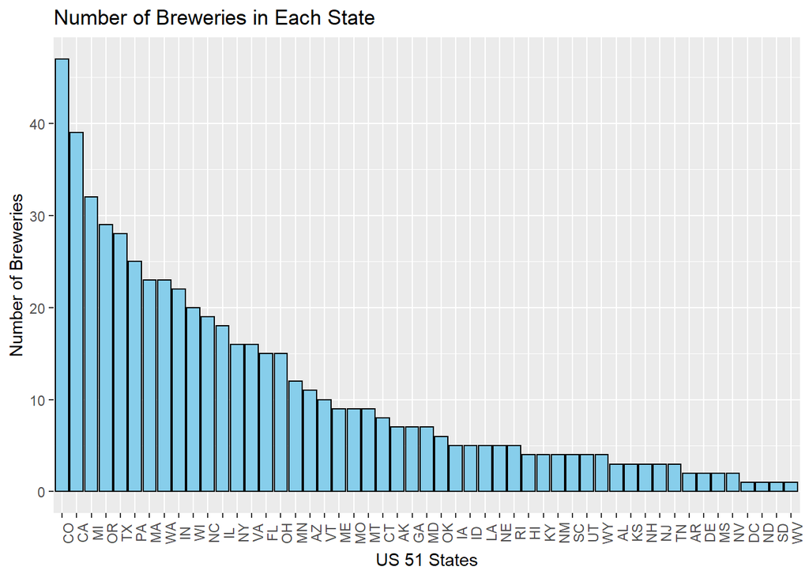

```r
#display in a bar chart
Brew_df%>%ggplot(aes(x=reorder(as.factor(State),-TotalBreweries),y=TotalBreweries)) +
  geom_col(fill="sky blue",color="black")+labs(x="US 51 States",y="Number of Breweries") +
  ggtitle("Number of Breweries in Each State") +
  theme(axis.text.x = element_text(angle = 90))
```

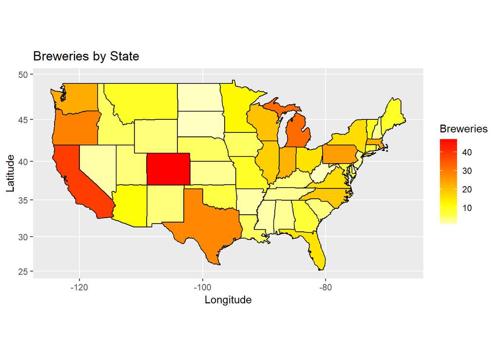

```r
#heat map
breweries2 = read.csv(file.choose())
lookup = data.frame(abb = state.abb, State = state.name) #make a dataframe of state names and abbreviations
colnames(breweries2)[4] = "abb" #change column name
breweries2$abb <- trimws(breweries2$abb, which = c("both")) #trim white space
breweries3 = merge(breweries2, lookup, by ="abb") #merge datasets
breweries_mapdata = count(breweries3, State) #count occurance of each state
colnames(breweries_mapdata)[2] = "Breweries" #change column name from "n" to "breweries"
breweries_mapdata$region <- tolower(breweries_mapdata$State) #create "region" column
breweries_mapdata = breweries_mapdata[-1] #remove states column
states <- map_data("state")
map.df <- merge(states, breweries_mapdata, by = "region", all.x = T)
map.df <- map.df[order(map.df$order),] #sort the data

ggplot(map.df, aes(x=long, y=lat, group=group)) +
  geom_polygon(aes(fill=Breweries)) + geom_path() +
  scale_fill_gradientn(colours=rev(heat.colors(10)),na.value="grey90") +
  ggtitle("Breweries by State") +labs(x="Longitude", y="Latitude") +
  coord_map()
```

Here is a barchart and a heat map displaying the number of breweries in each state. Colorado has the maximum number of breweries in United States with a count of 47. Other than Colorado, the states having most breweries are clustered along US border and coasts.The top 5 States with maximum breweries are Colorado, California, Michigan, Oregon, and Texas.The bottom 4 States with minimum breweries are DC, South Dakota, North Dakota, West Virginia, each with only one brewery in entire state.

Question 2: Merge the datasets

```r
Full_data=merge(Beers,Breweries, by="Brewery_id")
head(Full_data)
```

```
##   Brewery_id     Beer_Name Beer_ID   ABV IBU
## 1          1  Get Together    2692 0.045  50
## 2          1 Maggie's Leap    2691 0.049  26
## 3          1    Wall's End    2690 0.048  19
## 4          1       Pumpion    2689 0.060  38
## 5          1    Stronghold    2688 0.060  25
## 6          1   Parapet ESB    2687 0.056  47
##                                 Style Ounces       Brewery_Name        City
## 1                        American IPA     16 NorthGate Brewing  Minneapolis
## 2                  Milk / Sweet Stout     16 NorthGate Brewing  Minneapolis
## 3                   English Brown Ale     16 NorthGate Brewing  Minneapolis
## 4                         Pumpkin Ale     16 NorthGate Brewing  Minneapolis
## 5                     American Porter     16 NorthGate Brewing  Minneapolis
## 6 Extra Special / Strong Bitter (ESB)     16 NorthGate Brewing  Minneapolis
##   State
## 1    MN
## 2    MN
## 3    MN
## 4    MN
## 5    MN
## 6    MN
```

```r
tail(Full_data)
```

```
##      Brewery_id                 Beer_Name Beer_ID   ABV IBU
## 2405        556             Pilsner Ukiah      98 0.055  NA
## 2406        557  Heinnieweisse Weissebier      52 0.049  NA
## 2407        557           Snapperhead IPA      51 0.068  NA
## 2408        557         Moo Thunder Stout      50 0.049  NA
## 2409        557         Porkslap Pale Ale      49 0.043  NA
## 2410        558 Urban Wilderness Pale Ale      30 0.049  NA
##                        Style Ounces                  Brewery_Name          City
## 2405         German Pilsener     12         Ukiah Brewing Company         Ukiah
## 2406              Hefeweizen     12       Butternuts Beer and Ale Garrattsville
## 2407            American IPA     12       Butternuts Beer and Ale Garrattsville
## 2408      Milk / Sweet Stout     12       Butternuts Beer and Ale Garrattsville
## 2409 American Pale Ale (APA)     12       Butternuts Beer and Ale Garrattsville
## 2410        English Pale Ale     12 Sleeping Lady Brewing Company     Anchorage
##      State
## 2405    CA
## 2406    NY
## 2407    NY
## 2408    NY
## 2409    NY
## 2410    AK
```

```r
dim(Full_data)
```

```
## [1] 2410   10
```

Types of craft beers

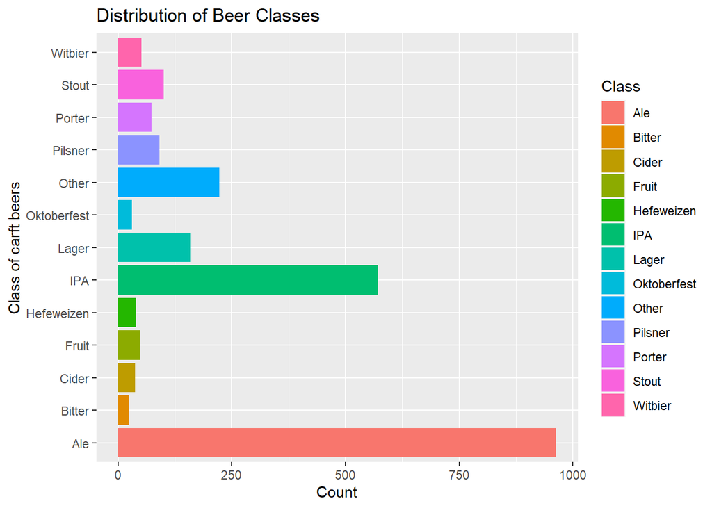

```r
Full_data["Class"] = ifelse(str_detect(Full_data$Style,"IPA"),"IPA",
                      ifelse(str_detect(Full_data$Style,"Ale"),"Ale",
                      ifelse(str_detect(Full_data$Style,"Lager"),"Lager",
                      ifelse(str_detect(Full_data$Style,"Stout"),"Stout",
                      ifelse(str_detect(Full_data$Style,"Pilsner"),"Pilsner",
                      ifelse(str_detect(Full_data$Style,"Pilsener"),"Pilsner",
                      ifelse(str_detect(Full_data$Style,"Porter"),"Porter",
                      ifelse(str_detect(Full_data$Style,"APA"),"APA",
                      ifelse(str_detect(Full_data$Style,"Cider"),"Cider",
                      ifelse(str_detect(Full_data$Style,"Witbier"),"Witbier",
                      ifelse(str_detect(Full_data$Style,"Kölsch"),"Kölsch",
                      ifelse(str_detect(Full_data$Style,"Fruit"),"Fruit",
                      ifelse(str_detect(Full_data$Style,"Hefeweizen"),"Hefeweizen",
                      ifelse(str_detect(Full_data$Style,"Oktoberfest"),"Oktoberfest",
                      ifelse(str_detect(Full_data$Style,"Bitter"),"Bitter",
                             "Other")))))))))))))))

Full_data%>%ggplot(aes(x = Class, fill=Class))+geom_bar()+
  ggtitle("Distribution of Beer Classes")+coord_flip()+xlab("Class of carft beers")+ylab("Count")
```

```r
total_beer=length(Full_data$Class)
total_beer
```

```
## [1] 2410
```

```r
total_IPA=sum(str_detect(Full_data$Class, "IPA"))
total_IPA
```

```
## [1] 571
```

```r
total_Ale=sum(str_detect(Full_data$Class, "Ale"))
total_Ale
```

```
## [1] 963
```

```r
total_IPA_Ale=((total_Ale+total_IPA)/total_beer)*100
total_IPA_Ale
```

```
## [1] 63.65145
```

There are 100 different style of craft beers brewed in the United States. Classes of Beer have style variants, i.e., Ales include English Pale, Irish Red, etc. When grouped into classes, IPA’s And Ales account for 64% of all craft beers.

Question 3: Address the missing values in each column

```r
#find out how many missing values there are in each column
d1=sum(is.na(Full_data$ABV))
d1#ABV has 62 NA values
```

```
## [1] 62
```

```r
d2=sum(is.na(Full_data$IBU))
d2#IBU has 1005 NA values
```

```
## [1] 1005
```

```r
d3=sum(is.na(Full_data$Beer_Name))
d3
```

```
## [1] 0
```

```r
d4=sum(is.na(Full_data$Style))
d4
```

```
## [1] 0
```

```r
d5=sum(is.na(Full_data$Ounces))
d5
```

```
## [1] 0
```

```r
d6=sum(is.na(Full_data$Brewery_Name))
d6
```

```
## [1] 0
```

```r
d7=sum(is.na(Full_data$City))
d7
```

```
## [1] 0
```

```r
d8=sum(is.na(Full_data$State))
d8
```

```
## [1] 0
```

```r
#visualize missing values
missing_values=data.frame(column=c("ABV","IBU","Beer_Name","Style","Ounces","Brewery_Name","City","State" ), count=c(d1,d2,d3,d4,d5,d6,d7,d8))
missing_values
```

```
##         column count
## 1          ABV    62
## 2          IBU  1005
## 3    Beer_Name     0
## 4        Style     0
## 5       Ounces     0
## 6 Brewery_Name     0
## 7         City     0
## 8        State     0
```

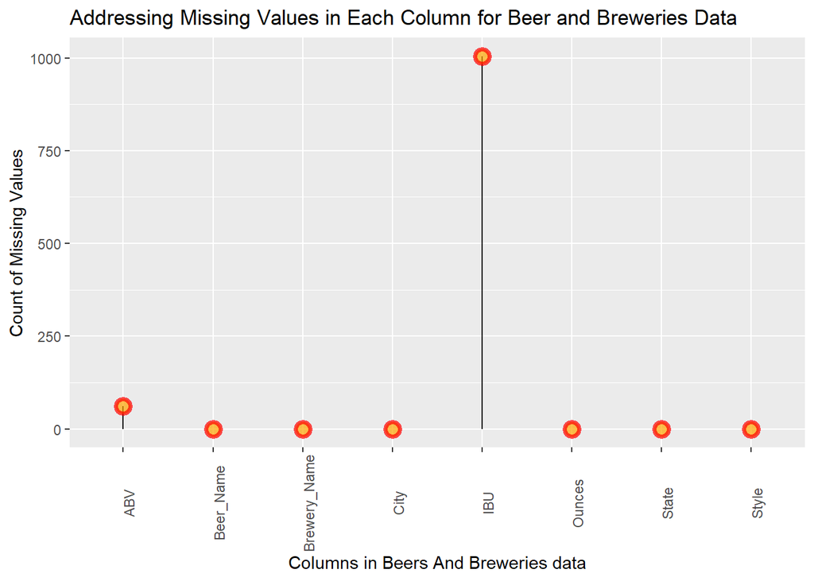

```r
ggplot(missing_values, aes(x=column, y=count)) +
  geom_segment( aes(x=column, xend=column, y=0, yend=count)) +
  geom_point( size=3, color="red", fill=alpha("orange", 0.3), alpha=0.7, shape=21, stroke=2)+
  labs(x="Columns in Beers And Breweries data", y="Count of Missing Values",title="Addressing Missing Values in Each Column for Beer and Breweries Data")+
theme(axis.text.x = element_text(angle = 90))
```

```r
#Boxplot of IBU  with NA values
#NA_df_IBU=ggplot(Full_data,aes(y=reorder(Class,-IBU),x=IBU)) +
#  geom_boxplot(fill="pink",color="black") +
#  labs(y="Beer Class",x="International Bitterness Unit") +
#  ggtitle("International Bitterness Unit by class") +
#  theme(axis.text.x = element_text(angle = 90))

#NA_df_IBU

#Boxplot of IBV with NA values
#NA_df_ABV=ggplot(Full_data,aes(y=reorder(Class,-ABV),x=ABV)) +
#  geom_boxplot(fill="dark green",color="black") +
#  labs(y="Beer Class",x="Alcohol by Volume") +
#  ggtitle("Alcohol by Volume by class") +
#  theme(axis.text.x = element_text(angle = 90))

#NA_df_ABV


#make a new column where null ABV values now have ABV mean
#imp = imputed
Full_data$ABV.imp.mean =ifelse(is.na(Full_data$ABV), mean(Full_data$ABV, na.rm=TRUE), Full_data$ABV)
head(Full_data$ABV.imp.mean)
```

```
## [1] 0.045 0.049 0.048 0.060 0.060 0.056
```

```r
sum(is.na(Full_data$ABV.imp.mean)) #no more NAs
```

```
## [1] 0
```

```r
#make a new column where null IBU values now have IBU mean
Full_data$IBU.imp.mean = ifelse(is.na(Full_data$IBU), mean(Full_data$IBU, na.rm=TRUE), Full_data$IBU)
head(Full_data$IBU.imp.mean)
```

```
## [1] 50 26 19 38 25 47
```

```r
sum(is.na(Full_data$IBU.imp.mean)) #no more NAs
```

```
## [1] 0
```

We found 62 null values in the ABV column (2.6%) and 1005 in the IBU column (42%). No IBU rating is available for South Dakota. Thinking the missing values would be close to the average, we replaced them with the averages of the present values.

Question 4: Compute and plot median alcohol content and international bitterness units for each state.

```r
#compute medians
Median_df_imp=Full_data%>%group_by(State)%>%summarise(median_ABV_imp=median(ABV.imp.mean), median_IBU_imp=median(IBU.imp.mean))
Median_df_imp=as.data.frame(Median_df_imp)
head(Median_df_imp)
```

```
##   State median_ABV_imp median_IBU_imp
## 1    AK     0.05600000       42.71317
## 2    AL     0.06000000       42.85658
## 3    AR     0.05200000       42.71317
## 4    AZ     0.05800000       42.71317
## 5    CA     0.05800000       42.71317
## 6    CO     0.05977342       42.71317
```

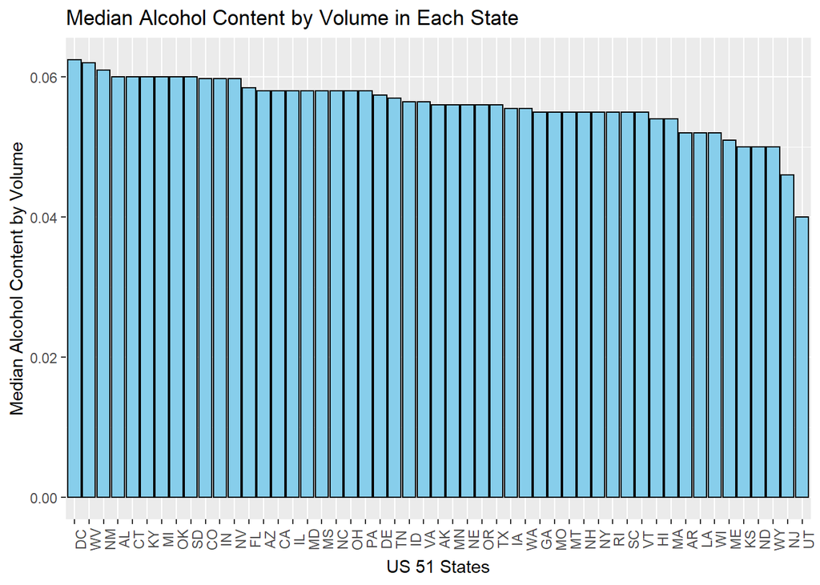

```r
#plot medians for ABV without na values
Median_df_ABV=ggplot(Median_df_imp,aes(x=reorder(State,-median_ABV_imp),y=median_ABV_imp)) +
  geom_col(fill="sky blue",color="black") +
  labs(x="US 51 States",y="Median Alcohol Content by Volume") +
  ggtitle("Median Alcohol Content by Volume in Each State") +
  theme(axis.text.x = element_text(angle = 90))

Median_df_ABV
```

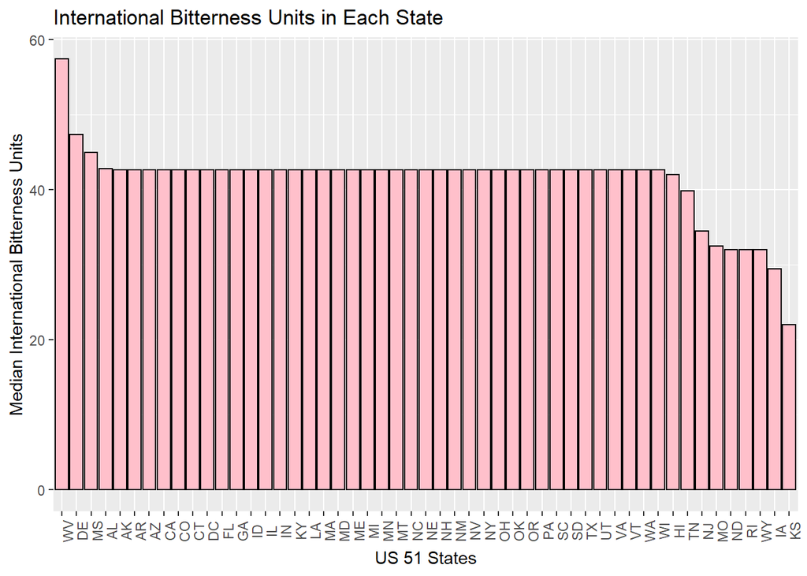

```r
#plot medians for IBU without na values
Median_df_IBU=ggplot(Median_df_imp,aes(x=reorder(State,-median_IBU_imp),y=median_IBU_imp)) +
  geom_col(fill="pink",color="black") +
  labs(x="US 51 States",y="Median International Bitterness Units") +
  ggtitle("International Bitterness Units in Each State") +
  theme(axis.text.x = element_text(angle = 90))

Median_df_IBU
```

```r
#table
Median_df_imp
```

```
##    State median_ABV_imp median_IBU_imp
## 1     AK     0.05600000       42.71317
## 2     AL     0.06000000       42.85658
## 3     AR     0.05200000       42.71317
## 4     AZ     0.05800000       42.71317
## 5     CA     0.05800000       42.71317
## 6     CO     0.05977342       42.71317
## 7     CT     0.06000000       42.71317
## 8     DC     0.06250000       42.71317
## 9     DE     0.05738671       47.35658
## 10    FL     0.05850000       42.71317
## 11    GA     0.05500000       42.71317
## 12    HI     0.05400000       42.00000
## 13    IA     0.05550000       29.50000
## 14    ID     0.05650000       42.71317
```

[output cut: 37 more lines]

Here we see the median alcohol contents and international bitterness units for each state (including Washington, D.C.). Median alcohol content by volume doesn’t appear to vary much by state, with most states having a median value between 0.05 and 0.06. The top 5 states with maximum median ABV are DC, West Virginia, New Mexico, Alabama, and Connecticut. The bottom 5 states with minimum median ABV are Kansas, North Dakota, Wyoming, New Jersey and Utah. For most states, the median IBU rating is in the low 40’s. The top 5 states with maximum median IBU are West Virginia, Delaware, Mississippi, Alabama, and Arkansas. The bottom 5 states with minimum median IBU are North Dakota, Rhode Island, Wyoming, Iowa, Kansas.

Question 5: Which state has the maximum alcoholic beer, and which has the most bitter beer?

```r
max.abv =Full_data %>% filter(ABV==max(Full_data$ABV,na.rm=TRUE)) %>% select(Beer_Name,ABV,Class,Style,State,Brewery_Name)
max.abv
```

```
##                                              Beer_Name   ABV Class
## 1 Lee Hill Series Vol. 5 - Belgian Style Quadrupel Ale 0.128 Other
##              Style State            Brewery_Name
## 1 Quadrupel (Quad)    CO Upslope Brewing Company
```

```r
#Answer Colorado, Lee Hill Series Vol.5, ABV = 0.128, Upslope Brewing Company
max.ibu = Full_data %>% filter(IBU==max(Full_data$IBU,na.rm=TRUE)) %>% select(Beer_Name,IBU,Class,Style,State,Brewery_Name)
max.ibu
```

```
##                   Beer_Name IBU Class                          Style State
## 1 Bitter Bitch Imperial IPA 138   IPA American Double / Imperial IPA    OR
##              Brewery_Name
## 1 Astoria Brewing Company
```

```r
#Answer Oregon, Bitter Bitch Imperial, IBU = 138
```

Question 6: Comment on the summary statistics

```r
#with NAs
summary_ABV=summary(Full_data$ABV)#for ABV
summary_ABV
```

```
##    Min. 1st Qu.  Median    Mean 3rd Qu.    Max.    NA's
## 0.00100 0.05000 0.05600 0.05977 0.06700 0.12800      62
```

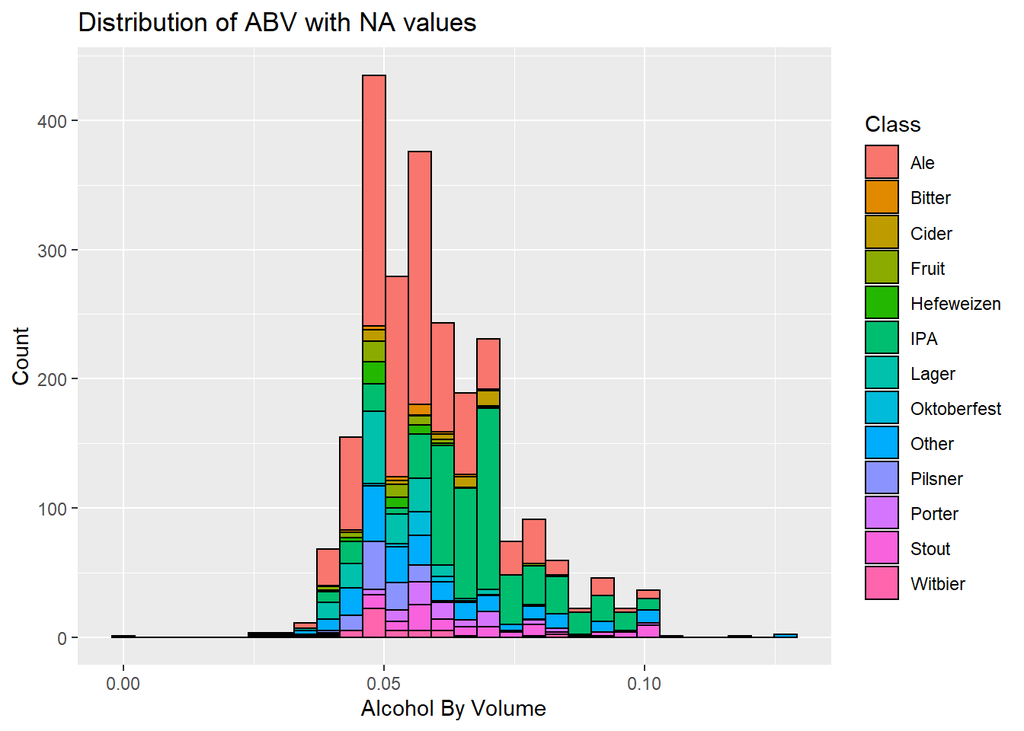

```r
ABV_histogram = Full_data %>% ggplot(aes(x = ABV, fill=Class)) +
  geom_histogram( color = "black") +
  ggtitle("Distribution of ABV with NA values")+labs(y="Count", x="Alcohol By Volume")
ABV_histogram
```

```r
#without NAs
summary_imp_ABV=summary(Full_data$ABV.imp.mean)#for ABV
summary_imp_ABV
```

```
##    Min. 1st Qu.  Median    Mean 3rd Qu.    Max.
## 0.00100 0.05000 0.05700 0.05977 0.06700 0.12800
```

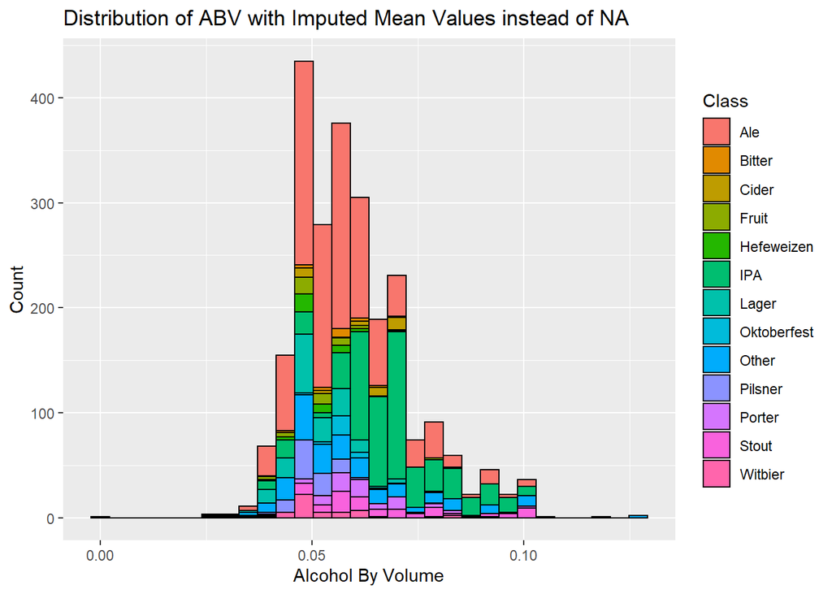

```r
ABV_imp_histogram = Full_data %>% ggplot(aes(x = ABV.imp.mean, fill=Class)) +
  geom_histogram(color="black") +
  ggtitle("Distribution of ABV with Imputed Mean Values instead of NA")+
  labs(y="Count", x="Alcohol By Volume")
ABV_imp_histogram
```

Our visual evidence suggests that the distribution of alcohol content by volume is slightly right skewed, but mostly normal. With our decision to replace the null values with the mean, only the median is affected of the summary statistics, and then only slightly. The skewness appears to come largely from IPAs, indicating that IPAs are more alcoholic than other beers.

Question 7: Is there a relationship between bitterness and alcohol content?

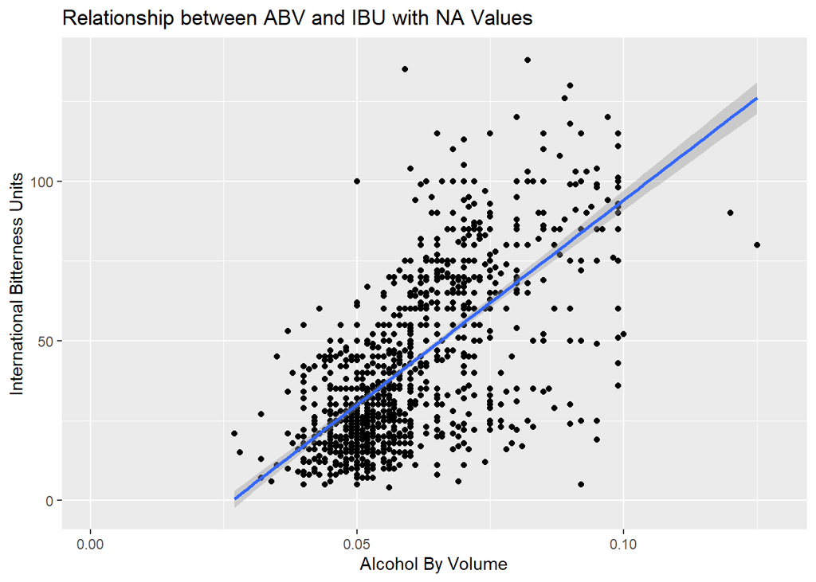

```r
#with NAs
IBU_ABV=ggplot(Full_data,aes(x=ABV, y=IBU)) +
  geom_point() +
  geom_smooth(method="lm") +
  ggtitle("Relationship between ABV and IBU with NA Values")+
  labs(x="Alcohol By Volume",y="International Bitterness Units")
IBU_ABV
```

```r
lm_full_data=lm(IBU~ABV, Full_data)
lm_full_data
```

```
##
## Call:
## lm(formula = IBU ~ ABV, data = Full_data)
##
## Coefficients:
## (Intercept)          ABV
##       -34.1       1282.0
```

```r
summary(lm_full_data)
```

```
##
## Call:
## lm(formula = IBU ~ ABV, data = Full_data)
##
## Residuals:
##     Min      1Q  Median      3Q     Max
## -78.849 -11.977  -0.721  13.997  93.458
##
## Coefficients:
##             Estimate Std. Error t value Pr(>|t|)
## (Intercept)  -34.099      2.326  -14.66   <2e-16 ***
## ABV         1282.037     37.860   33.86   <2e-16 ***
## ---
## Signif. codes:  0 '***' 0.001 '**' 0.01 '*' 0.05 '.' 0.1 ' ' 1
##
## Residual standard error: 19.26 on 1403 degrees of freedom
##   (1005 observations deleted due to missingness)
## Multiple R-squared:  0.4497, Adjusted R-squared:  0.4493
## F-statistic:  1147 on 1 and 1403 DF,  p-value: < 2.2e-16
```

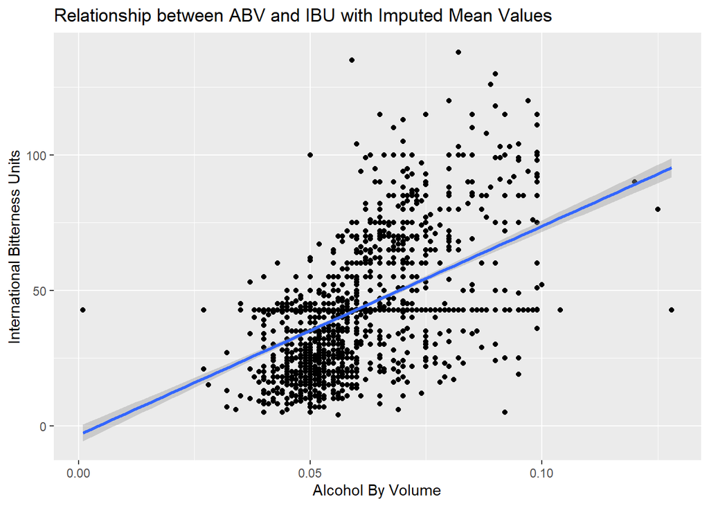

```r
#without NAs
imp_IBU_ABV=ggplot(Full_data,aes(x=ABV.imp.mean, y=IBU.imp.mean)) +
  geom_point() +
  geom_smooth(method="lm") +
  ggtitle("Relationship between ABV and IBU with Imputed Mean Values")+
  labs(x="Alcohol By Volume",y="International Bitterness Units")
imp_IBU_ABV
```

```r
lm_full_data_imp=lm(IBU.imp.mean~ABV.imp.mean, Full_data)
lm_full_data_imp
```

```
##
## Call:
## lm(formula = IBU.imp.mean ~ ABV.imp.mean, data = Full_data)
##
## Coefficients:
##  (Intercept)  ABV.imp.mean
##       -3.363       770.851
```

```r
summary(lm_full_data_imp)
```

```
##
## Call:
## lm(formula = IBU.imp.mean ~ ABV.imp.mean, data = Full_data)
##
## Residuals:
##     Min      1Q  Median      3Q     Max
## -62.555 -12.492   0.000   9.498  92.883
##
## Coefficients:
##              Estimate Std. Error t value Pr(>|t|)
## (Intercept)    -3.363      1.580  -2.128   0.0334 *
## ABV.imp.mean  770.851     25.803  29.875   <2e-16 ***
## ---
## Signif. codes:  0 '***' 0.001 '**' 0.01 '*' 0.05 '.' 0.1 ' ' 1
##
## Residual standard error: 16.93 on 2408 degrees of freedom
## Multiple R-squared:  0.2704, Adjusted R-squared:  0.2701
## F-statistic: 892.5 on 1 and 2408 DF,  p-value: < 2.2e-16
```

There appears to be a positive relationship between alcohol content by volume and international bitterness units.This is true regardless of whether we use the imputed null values, though less of the IBU variability is explained by the alcohol content with the imputed values (27% with imputed values vs. 45% without). Perhaps this relationship is positive because breweries wish to balance the sugar content (which makes beer more alcoholic with the fermentation process) with the hops content (which can make beer bitter). Or perhaps it is that many people find alcohol (ethanol) to be bitter.

Question 8: Investigate the difference between IPAs and other Ales using KNN

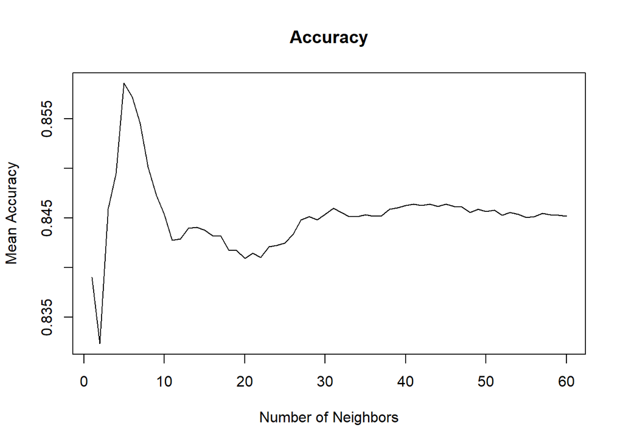

```r
Full_data["Class2"] = ifelse(str_detect(Full_data$Style,"IPA"),"IPA",
                      ifelse(str_detect(Full_data$Style,"Ale"),"Ale",
                        ifelse(str_detect(Full_data$Style, "APA"), "Ale",
                        NA
                       )))

just_ales = na.omit(Full_data, cols = c("Class2"))
#head(just_ales)

#knn classifier
set.seed(877)
iterations = 100
numks = 60
splitPerc = .70
masterAcc = matrix(nrow = iterations, ncol = numks)
masterSens = matrix(nrow = iterations, ncol = numks)
masterSpec = matrix(nrow = iterations, ncol = numks)
for(j in 1:iterations)
{
  accs = data.frame(accuracy = numeric(60), k = numeric(60))
  trainIndices = sample(1:dim(just_ales)[1],round(splitPerc * dim(just_ales[1])))
  train = just_ales[trainIndices,]
  test = just_ales[-trainIndices,]
  for(i in 1:numks)
  {
    classifications = knn(train[,c("IBU.imp.mean","ABV.imp.mean")],test[,c("IBU.imp.mean","ABV.imp.mean")],train$Class2, prob = TRUE, k = i)
    table(classifications,test$Class2)
    CM = confusionMatrix(table(classifications,test$Class))
    masterAcc[j,i] = CM$overall[1]
    masterSens[j,i] = mean(CM$byClass[1])
    masterSpec[j,i] = mean(CM$byClass[2])
  }

}



MeanAcc = colMeans(masterAcc)
MeanSens = colMeans(masterSens)
MeanSpec = colMeans(masterSpec)


#which is the best k
plot(seq(1,numks,1),MeanAcc, type = "l", main = "Accuracy", ylab = "Mean Accuracy", xlab = "Number of Neighbors")
```

```r
which.max(MeanAcc)
```

```
## [1] 5
```

```r
max(MeanAcc) #Accuracy with k=5
```

```
## [1] 0.8585866
```

```r
MeanSens[5] #Sensitivity with k=5
```

```
## [1] 0.8894598
```

```r
MeanSpec[5] #Specificity with k=5
```

```
## [1] 0.8155353
```

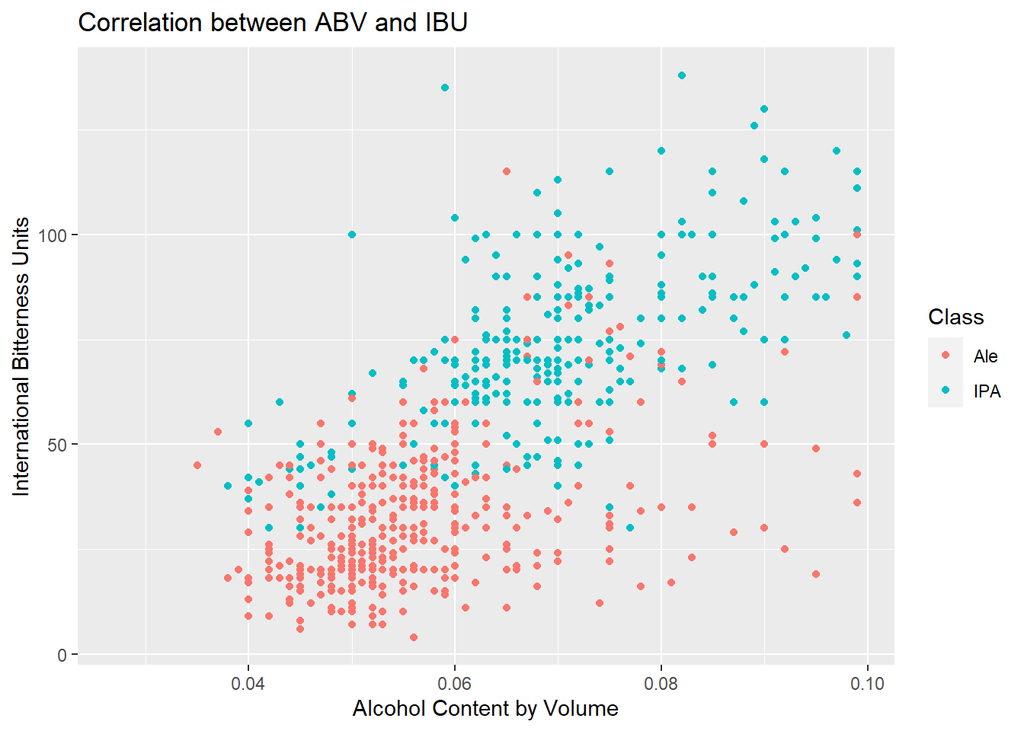

```r
Full_data %>% filter(Class == "IPA" | Class == "Ale") %>% ggplot(mapping=aes(y=IBU, x=ABV,color=Class)) + geom_point()+ labs(y="International Bitterness Units",x="Alcohol Content by Volume",title="Correlation between ABV and IBU")
```

We trained our KNN model with 100 iterations to find the number of neighbors with the highest accuracy. We found that to be k=5. Given ABV and IBU, our KNN model has over an 85% accuracy rate–that is the number of beers correctly classified as either IPA or other Ale. The model has a sensitivity of over 88%–that is of the Ales, over 88% were identified correctly. Finally, the model has a specificity of over 81%–that is, of the IPAs, over 81% were identified correctly.

Question 9: Provide extra insights

Insight 1: “ABV and IBU relationship for IPA and Ale”

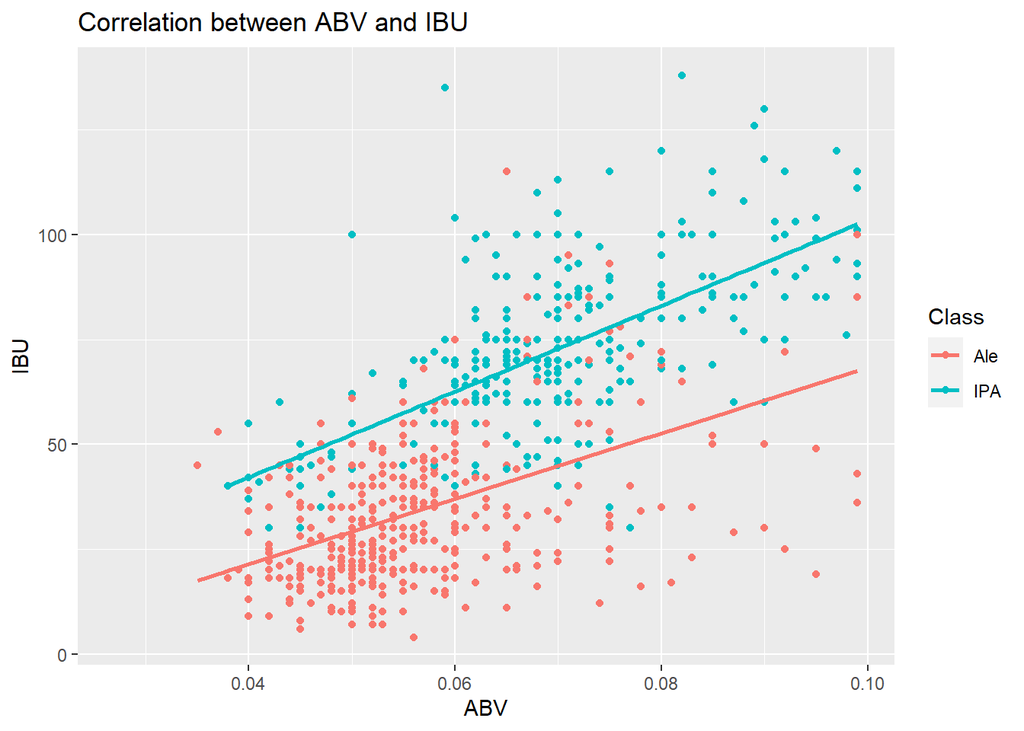

```r
Full_data %>% filter(Class == "IPA" | Class == "Ale") %>% ggplot(mapping=aes(y=IBU, x=ABV,color=Class)) + geom_point()+ geom_smooth(method="lm",se=FALSE,size=1)+ labs(title="Correlation between ABV and IBU")
```

```r
ipa=Full_data %>% filter(Class == "IPA")
#ipa
fit_ipa=lm(ABV~IBU,data=ipa)
summary(fit_ipa)
```

```
##
## Call:
## lm(formula = ABV ~ IBU, data = ipa)
##
## Residuals:
##       Min        1Q    Median        3Q       Max
## -0.035112 -0.005484 -0.000441  0.005594  0.027253
##
## Coefficients:
##              Estimate Std. Error t value Pr(>|t|)
## (Intercept) 0.0406499  0.0018115   22.44   <2e-16 ***
## IBU         0.0003960  0.0000243   16.30   <2e-16 ***
## ---
## Signif. codes:  0 '***' 0.001 '**' 0.01 '*' 0.05 '.' 0.1 ' ' 1
##
## Residual standard error: 0.009391 on 390 degrees of freedom
##   (179 observations deleted due to missingness)
## Multiple R-squared:  0.4051, Adjusted R-squared:  0.4036
## F-statistic: 265.6 on 1 and 390 DF,  p-value: < 2.2e-16
```

```r
ale=Full_data %>% filter(Class == "Ale")
#ale
fit_ale=lm(ABV~IBU,data=ale)
summary(fit_ale)
```

```
##
## Call:
## lm(formula = ABV ~ IBU, data = ale)
##
## Residuals:
##       Min        1Q    Median        3Q       Max
## -0.025144 -0.005762 -0.001514  0.002734  0.043034
##
## Coefficients:
##              Estimate Std. Error t value Pr(>|t|)
## (Intercept) 0.0462786  0.0008949   51.71   <2e-16 ***
## IBU         0.0002993  0.0000231   12.96   <2e-16 ***
## ---
## Signif. codes:  0 '***' 0.001 '**' 0.01 '*' 0.05 '.' 0.1 ' ' 1
##
## Residual standard error: 0.009745 on 550 degrees of freedom
##   (411 observations deleted due to missingness)
## Multiple R-squared:  0.234,  Adjusted R-squared:  0.2326
## F-statistic:   168 on 1 and 550 DF,  p-value: < 2.2e-16
```

```r
ale_ounce=Full_data %>%group_by(Class,Ounces)%>%filter(Class == "Ale")
summary(ale_ounce)
```

```
##    Brewery_id     Beer_Name            Beer_ID            ABV
##  Min.   :  1.0   Length:963         Min.   :   1.0   Min.   :0.03500
##  1st Qu.: 93.0   Class :character   1st Qu.: 756.5   1st Qu.:0.05000
##  Median :205.0   Mode  :character   Median :1350.0   Median :0.05500
##  Mean   :235.9                      Mean   :1378.0   Mean   :0.05681
##  3rd Qu.:369.0                      3rd Qu.:2053.5   3rd Qu.:0.06000
##  Max.   :558.0                      Max.   :2690.0   Max.   :0.09900
##                                                      NA's   :31
##       IBU            Style               Ounces      Brewery_Name
##  Min.   :  4.00   Length:963         Min.   :12.00   Length:963
##  1st Qu.: 20.00   Class :character   1st Qu.:12.00   Class :character
##  Median : 30.00   Mode  :character   Median :12.00   Mode  :character
##  Mean   : 34.33                      Mean   :13.47
##  3rd Qu.: 44.25                      3rd Qu.:16.00
##  Max.   :115.00                      Max.   :32.00
##  NA's   :411
##      City              State              Class            ABV.imp.mean
##  Length:963         Length:963         Length:963         Min.   :0.03500
##  Class :character   Class :character   Class :character   1st Qu.:0.05000
##  Mode  :character   Mode  :character   Mode  :character   Median :0.05500
##                                                           Mean   :0.05691
##                                                           3rd Qu.:0.06000
##                                                           Max.   :0.09900
##
##   IBU.imp.mean       Class2
##  Min.   :  4.00   Length:963
##  1st Qu.: 27.50   Class :character
##  Median : 42.71   Mode  :character
##  Mean   : 37.91
##  3rd Qu.: 42.71
##  Max.   :115.00
##
```

```r
ipa_ounce=Full_data %>%group_by(Class,Ounces)%>%filter(Class == "IPA")
summary(ipa_ounce)
```

```
##    Brewery_id     Beer_Name            Beer_ID          ABV
##  Min.   :  1.0   Length:571         Min.   :   4   Min.   :0.02700
##  1st Qu.: 87.5   Class :character   1st Qu.: 868   1st Qu.:0.06200
##  Median :206.0   Mode  :character   Median :1603   Median :0.06800
##  Mean   :224.8                      Mean   :1494   Mean   :0.06879
##  3rd Qu.:344.5                      3rd Qu.:2089   3rd Qu.:0.07500
##  Max.   :557.0                      Max.   :2692   Max.   :0.09900
##                                                    NA's   :11
##       IBU            Style               Ounces      Brewery_Name
##  Min.   : 30.00   Length:571         Min.   :12.00   Length:571
##  1st Qu.: 60.00   Class :character   1st Qu.:12.00   Class :character
##  Median : 70.00   Mode  :character   Median :12.00   Mode  :character
##  Mean   : 71.95                      Mean   :13.75
##  3rd Qu.: 85.00                      3rd Qu.:16.00
##  Max.   :138.00                      Max.   :32.00
##  NA's   :179
##      City              State              Class            ABV.imp.mean
##  Length:571         Length:571         Length:571         Min.   :0.02700
##  Class :character   Class :character   Class :character   1st Qu.:0.06200
##  Mode  :character   Mode  :character   Mode  :character   Median :0.06800
##                                                           Mean   :0.06862
##                                                           3rd Qu.:0.07500
##                                                           Max.   :0.09900
##
##   IBU.imp.mean       Class2
##  Min.   : 30.00   Length:571
##  1st Qu.: 42.71   Class :character
##  Median : 61.00   Mode  :character
##  Mean   : 62.78
##  3rd Qu.: 75.00
##  Max.   :138.00
##
```

For IPAs, the relationship between ABV and IBU is once again positive, with an estimated 41% of variation in IBU attributed to ABV. For other ales, a positive relationship, with an estimated 24% of variation in IBU attributed to ABV.

Insight 2: Alcohol consumption per capita per brewery

```r
alcohol_cons = read.csv(file.choose()) #data collected from https://vinepair.com/articles/map-states-drink-alcohol-america-2020/
lookup = data.frame(abb = state.abb, State = state.name) #make a dataframe of state names and abbreviations
alcohol_cons$State <- trimws(alcohol_cons$State, which = c("both")) #trim white space
alcohol_cons2 = merge(alcohol_cons, lookup, by ="State") #merge datasets
colnames(alcohol_cons2)[3] = "Gallons" #change column name
alcohol_cons2$Gallons = str_replace(alcohol_cons2$Gallons, "M", "") #remove M
alcohol_cons2$Gallons = as.numeric(alcohol_cons2$Gallons) #make numeric
alcohol_cons2$region <- tolower(alcohol_cons2$State) #create "region" column
alcohol_cons2 = alcohol_cons2[-1] #remove states column
nd = c("47", 2, "ND", "north dakota") #add north dakota back in
names(nd) = c("Rank", "Gallons", "abb", "region")
alcohol_cons2 = rbind(alcohol_cons2, nd)
alcohol_cons2 = alcohol_cons2[-1]
alcohol_cons2$Gallons = as.numeric(alcohol_cons2$Gallons) #make numeric again
#states <- map_data("state")
#map.df <- merge(states, alcohol_cons2, by = "region", all.x = T)
#map.df <- map.df[order(map.df$order),] #sort the data
#ggplot(map.df, aes(x=long, y=lat, group=group)) +
#  geom_polygon(aes(fill=Gallons)) + geom_path() +
#  scale_fill_gradientn(colours=rev(hcl.colors(10, palette = "Emrld")),na.value="grey90") +
#  ggtitle("Total Alcohol Consumption by State") +labs(x="Longitude", y="Latitude")
#  coord_map()


Brew_df$State <- trimws(Brew_df$State, which = c("both"))

#alcohol consumption per brewery
ac_pc_pb = merge(Brew_df, alcohol_cons2, by.x = "State", by.y = "abb")

ac_pc_pb2 = ac_pc_pb %>% summarise(State = State, ac_pc_pb = Gallons/n())

ac_pc_pb2
```

```
##    State ac_pc_pb
## 1     AK    0.034
## 2     AL    0.160
## 3     AR    0.088
## 4     AZ    0.266
## 5     CA    1.624
## 6     CO    0.272
## 7     CT    0.146
## 8     DE    0.058
## 9     FL    0.940
## 10    GA    0.328
## 11    HI    0.062
## 12    IA    0.124
## 13    ID    0.082
## 14    IL    0.504
```

[output cut: 36 more lines]

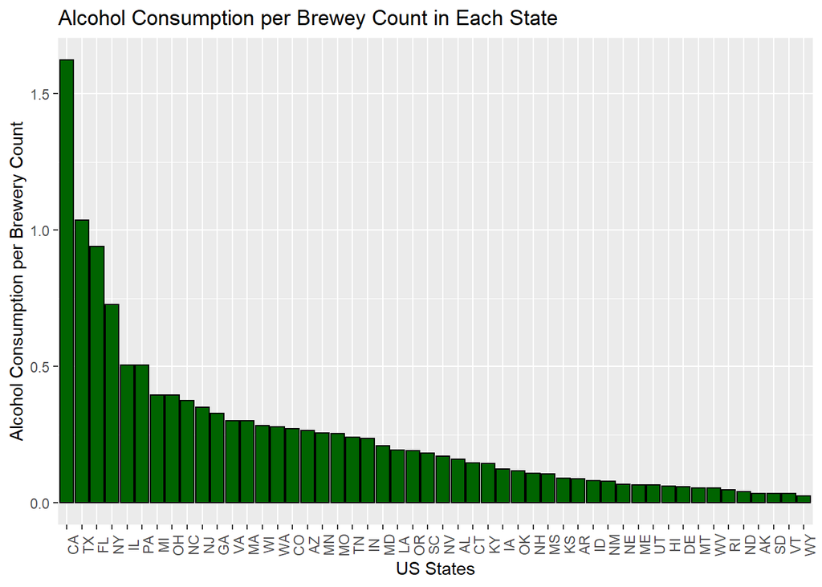

```r
#histogram
ggplot(ac_pc_pb2,aes(x=reorder(as.factor(State),-ac_pc_pb), y=ac_pc_pb))+
  geom_col(fill="dark green", color="black")+
  labs(x="US States",y="Alcohol Consumption per Brewery Count") +
  ggtitle("Alcohol Consumption per Brewey Count in Each State") +
  theme(axis.text.x = element_text(angle = 90))
```

```r
order1=ac_pc_pb%>%summarise(ac_pc_pb=ac_pc_pb$Gallons/n())
order1
```

```
##    ac_pc_pb
## 1     0.034
## 2     0.160
## 3     0.088
## 4     0.266
## 5     1.624
## 6     0.272
## 7     0.146
## 8     0.058
## 9     0.940
## 10    0.328
## 11    0.062
## 12    0.124
## 13    0.082
## 14    0.504
```

[output cut: 36 more lines]

```r
sort1=sort(order1$ac_pc_pb, decreasing = TRUE)
sort1
```

```
##  [1] 1.624 1.036 0.940 0.726 0.504 0.504 0.394 0.394 0.374 0.350 0.328 0.302
## [13] 0.300 0.284 0.278 0.272 0.266 0.256 0.254 0.240 0.236 0.208 0.194 0.192
## [25] 0.182 0.170 0.160 0.146 0.144 0.124 0.118 0.108 0.106 0.090 0.088 0.082
## [37] 0.078 0.068 0.066 0.066 0.062 0.058 0.054 0.054 0.048 0.040 0.034 0.034
## [49] 0.034 0.026
```

```r
summary(sort1)
```

```
##    Min. 1st Qu.  Median    Mean 3rd Qu.    Max.
##  0.0260  0.0705  0.1760  0.2539  0.2960  1.6240
```

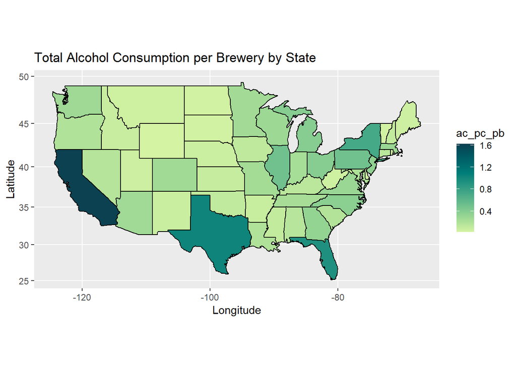

```r
#heatmap
lookup = data.frame(abb = state.abb, State = state.name) #make a dataframe of state names and abbreviations
ac_pc_pb2$State <- trimws(ac_pc_pb2$State, which = c("both"))
colnames(ac_pc_pb2)[1] = "abb"
alcohol_cons2$abb <- trimws(alcohol_cons2$abb, which = c("both"))
ac_pc_pb3 = merge(ac_pc_pb2, lookup, by = "abb") #merge datasets
ac_pc_pb3$region <- tolower(ac_pc_pb3$State) #create "region" column

ac_pc_pb3 = ac_pc_pb3 %>% select(abb, ac_pc_pb, region)

states <- map_data("state")
map.df <- merge(states, ac_pc_pb3, by = "region", all.x = T)
map.df <- map.df[order(map.df$order),] #sort the data

ggplot(map.df, aes(x=long, y=lat, group=group)) +
  geom_polygon(aes(fill=ac_pc_pb)) + geom_path() +
  scale_fill_gradientn(colours=rev(hcl.colors(10, palette = "Emrld")),na.value="grey90") +
  ggtitle("Total Alcohol Consumption per Brewery by State") +labs(x="Longitude", y="Latitude") +
  coord_map()
```

```r
total_gallons=sum(alcohol_cons2$Gallons)
total_gallons
```

```
## [1] 634.8
```

```r
top5=sort(alcohol_cons2$Gallons, decreasing = TRUE)
top5_df=as.data.frame(top5)
top5_data=top5_df%>%top_n(5)
top5_data
```

```
##   top5
## 1 81.2
## 2 51.8
## 3 47.0
## 4 36.3
## 5 25.2
## 6 25.2
```

```r
total_top5=(sum(top5_data)/total_gallons)*100
total_top5
```

```
## [1] 42.01323
```

```r
bottom5=sort(alcohol_cons2$Gallons, decreasing = TRUE)
bottom5
```

```
##  [1] 81.2 51.8 47.0 36.3 25.2 25.2 19.7 19.7 18.7 17.5 16.4 15.1 15.0 14.2 13.9
## [16] 13.6 13.3 12.8 12.7 12.0 11.8 10.4  9.7  9.6  9.1  8.5  8.0  7.3  7.2  6.2
## [31]  5.9  5.4  5.3  4.5  4.4  4.1  3.9  3.4  3.3  3.3  3.1  2.9  2.7  2.7  2.4
## [46]  2.0  1.7  1.7  1.7  1.3
```

```r
bottom5_df=as.data.frame(bottom5)
bottom5_data=bottom5_df%>%top_n(-5)
bottom5_data
```

```
##   bottom5
## 1     2.0
## 2     1.7
## 3     1.7
## 4     1.7
## 5     1.3
```

```r
total_bottom5=(sum(bottom5_data)/total_gallons)*100
total_bottom5
```

```
## [1] 1.323251
```